# Visualization using R language

Lucie Hošková

## Programme

- short introduction and organization window aka Where Can You Find The Coffee
- R basics 101 review
- so what type of data am I actually working with and why do I need to know?
- basic plot types
- base R vs `ggplot2`
- `ggplot2` barplot, histogram, scatterplot and boxplot
- heatmaps
- maps

## Organization

- four cca 50 minutes long blocks with breaks in-between
  - water and coffee available
- combination of code along, presentation and individual work
- focused on those who already know the basics of operating with R (and RStudio); loading data, data types and structures, basic functions

## R basics recap - what do you know?

**What does the symbol $ do?**

$ selects values of a particular column from the dataframe

`dataframe$columnName`

**Which deliminator is used in R?**

Decimal point; however, that does not mean that you cannot use datasets which use comma.

**Which function can we use to load datasets from .txt or .csv files into R?**

`read.table()`

For txt: `read.delim()`

For CSV: `read.csv()`

**What are factors?**

Variables with set of possible values; represents categorical data.

```r
head(iris)
```

```
  Sepal.Length Sepal.Width Petal.Length Petal.Width Species
1          5.1         3.5          1.4         0.2  setosa
2          4.9         3.0          1.4         0.2  setosa
3          4.7         3.2          1.3         0.2  setosa
4          4.6         3.1          1.5         0.2  setosa
5          5.0         3.6          1.4         0.2  setosa
6          5.4         3.9          1.7         0.4  setosa
```

```r
iris$Species
```

```
  [1] setosa     setosa     setosa     setosa     setosa     setosa
  [7] setosa     setosa     setosa     setosa     setosa     setosa
 [13] setosa     setosa     setosa     setosa     setosa     setosa
 [19] setosa     setosa     setosa     setosa     setosa     setosa
 [25] setosa     setosa     setosa     setosa     setosa     setosa
 [31] setosa     setosa     setosa     setosa     setosa     setosa
 [37] setosa     setosa     setosa     setosa     setosa     setosa
 [43] setosa     setosa     setosa     setosa     setosa     setosa
 [49] setosa     setosa     versicolor versicolor versicolor versicolor
 [55] versicolor versicolor versicolor versicolor versicolor versicolor
 [61] versicolor versicolor versicolor versicolor versicolor versicolor
 [67] versicolor versicolor versicolor versicolor versicolor versicolor
 [73] versicolor versicolor versicolor versicolor versicolor versicolor
 [79] versicolor versicolor versicolor versicolor versicolor versicolor
 [85] versicolor versicolor versicolor versicolor versicolor versicolor
 [91] versicolor versicolor versicolor versicolor versicolor versicolor
 [97] versicolor versicolor versicolor versicolor virginica  virginica
[103] virginica  virginica  virginica  virginica  virginica  virginica
[109] virginica  virginica  virginica  virginica  virginica  virginica
[115] virginica  virginica  virginica  virginica  virginica  virginica
[121] virginica  virginica  virginica  virginica  virginica  virginica
[127] virginica  virginica  virginica  virginica  virginica  virginica
[133] virginica  virginica  virginica  virginica  virginica  virginica
[139] virginica  virginica  virginica  virginica  virginica  virginica
[145] virginica  virginica  virginica  virginica  virginica  virginica
Levels: setosa versicolor virginica
```

```r
levels(iris$Species)
```

```
[1] "setosa"     "versicolor" "virginica"
```

## Types of data

Why it is important to know the difference? **Because the type of your data will infuence what visualization can be used.** You can hardly portray a categorical data like number of individuals for each blood type category using a linechart.

### Categorial (qualitative) data

Data which has a certain quality; in other words, data which can be divided into categories.

- **nominal data**
  - data that can be divided into categories, that cannot be ordered - cannot be compared and ranked
    - blood type, eyecolour, type of cell staining
- **ordinal data**
  - data that can be divided into categories and can be put into an order - one category can be put above the other
    - newborn, toddler, child, teenager, adult, senior
    - first, second, third

### Numeric (quantitative) data

Data which can be counted and measured

- **interval data**
  - data that can be described as values differing by a set interval
    - the difference between 182 and 183 is exactly 1, same as 87 and 88 - in both cases the difference between those intervals is exactly the same (1 = 1)
    - tldr; standard numeric values from negative infinity to úositive infinity
  - degrees of Celsius, altitude above the sea level
- **ratio**
  - data that can be described as values differing by a set interval, with a defined zero value, which allows to create size comparison/ratio
    - an example is weight; something cannot exactly be negative grams
    - x weights 20 grams, y 40 grams, with the later being twice as heavy as x
      - why canť the same be done with degrees of Celsius? What other unit of measurements would have to be used?
    - length of bone, number of samples collected

**Is it possible to change the data type?**

Yes, for example by changing the interval or ratio data into ordinal data; height in centimeters get changed into 50 cm difference categories.

## Loading the data

During this workshop, we will be working with many types of datasets, most of which are saved in various packages. The first one that we will be however using is the dataset in the file [`newborns.txt`](https://luc-hoskova.github.io/R-individualni_kurzy/Charleston-visualization/newborns.txt).

To be able to create visualizations based on the information within, we first have to **load it into our instance of R**.

**Always check your data!**

Just loading the data is never enough; always check the data to make sure that **each variable is the correct data type**; for example, the categorical data are set as factors, not just character or numeric values.

## Base R vizualization

While we will be using primarily `ggplot2` package for visualization, it is handy to know the basics of visualization using just the basic R functions, at least for the three most common plot types: barplot, histogram, and line chart.

### Barplot

A barplot is used to display the relationship between a **numeric and a categorical variable**.

In this example, we are using the categorial data of different education levels of the mothers (`edu.M`) and the numeric value that is the count of the occurences for each category.

```r
barplot(table(dataNewborns$edu.M),
  xlab = "Mother's education", #x axis description
  ylab = "Frequency", #y axis description
  main = "Distribution of edu.M", #plot title
  col = c("lightblue", "magenta", "yellow", "red")) #colors
```

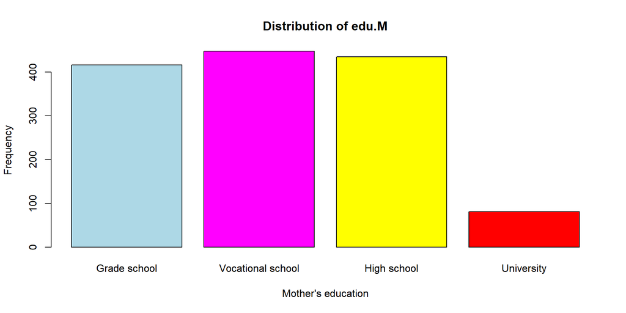

### Histogram

A histogram is used to study the **distribution of one or several variables**. Distribution can be only applied to numeric data!

```r
hist(dataNewborns$weight.C,
     breaks = 11, #number of bins
     labels = TRUE, #label the value of each bin
     ylim = c(0, 500), #set y axis limits - how high the axis can go
    )
```

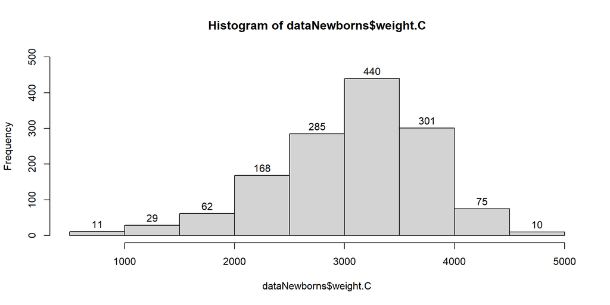

### Line chart

A line chart (or line graph) is a graph that displays **relationship between numeric values**, in the point of continuous line, ie. the stereotypical graph.

Line chart is used mainly when the **x-axis has a natural order** and you want to show a trend or change.

For this example we will be using inbuilt dataset `Nile`, containing time series of the annual flow of the Nile river. To understand it, first lets take a look at it.

```r
Nile
```

```
Time Series:
Start = 1871
End = 1970
Frequency = 1
  [1] 1120 1160  963 1210 1160 1160  813 1230 1370 1140  995  935 1110  994 1020
 [16]  960 1180  799  958 1140 1100 1210 1150 1250 1260 1220 1030 1100  774  840
 [31]  874  694  940  833  701  916  692 1020 1050  969  831  726  456  824  702
 [46] 1120 1100  832  764  821  768  845  864  862  698  845  744  796 1040  759
 [61]  781  865  845  944  984  897  822 1010  771  676  649  846  812  742  801
 [76] 1040  860  874  848  890  744  749  838 1050  918  986  797  923  975  815
 [91] 1020  906  901 1170  912  746  919  718  714  740
```

From this we can clearly see continuous nature of the data.

```r
plot(Nile,
  type = "l", #show only line
  col = "steelblue", #color of kine
  lwd = 2, #line width
  xlab = "Year",
  ylab = "River flow",
  main = "Annual Flow of the Nile River")
```

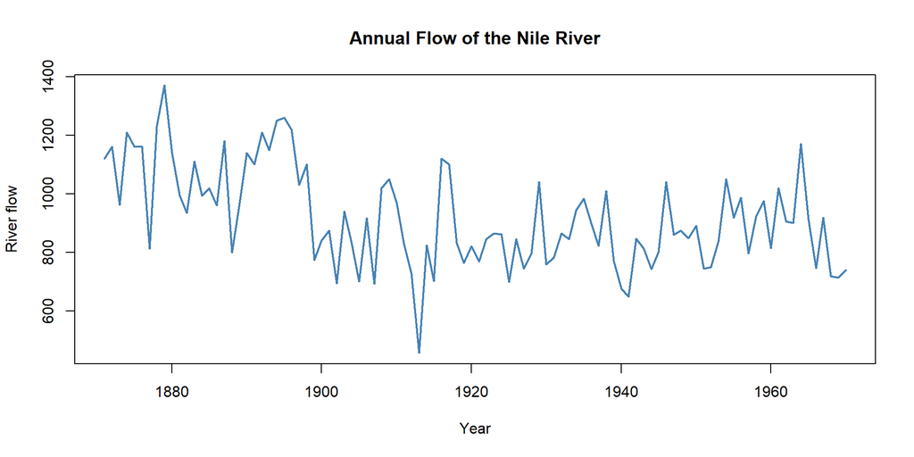

### Scatter plot

Another visualization comparing two numerical values is scatterplot; unlike line chart, which compares when you want to show the relationship between **two numeric variables, usually of individual measurements/observations.**

For this example we will use the inbuilt dataframe `iris`, which describes the petal width and length of various flowers. Lets take a look at it.

```r
head(iris)
```

```
  Sepal.Length Sepal.Width Petal.Length Petal.Width Species
1          5.1         3.5          1.4         0.2  setosa
2          4.9         3.0          1.4         0.2  setosa
3          4.7         3.2          1.3         0.2  setosa
4          4.6         3.1          1.5         0.2  setosa
5          5.0         3.6          1.4         0.2  setosa
6          5.4         3.9          1.7         0.4  setosa
```

We can see that the dataset contains multiple measurements, not just a continuous line.

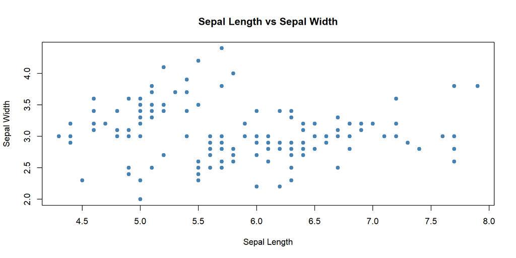

```r
plot(
  iris$Sepal.Length,
  iris$Sepal.Width,
  type = "p", #show only points
  pch = 19, #type of the points (round and col filled)
  col = "steelblue", #color of the points
  xlab = "Sepal Length",
  ylab = "Sepal Width",
  main = "Sepal Length vs Sepal Width")
```

**Numeric data type does not automatically equal quantitative data!**

Do not forget that **even “numbers” can be qualitative data**.  
In this case, the variable `prch.N` aka the number of pregnancies before the birth of the child isn´t a continuous line of numbers, but rather distinct categories; is it a first pregnancy, second, third, and so on?  
For context look back to the part Categorial (qualitative) data.

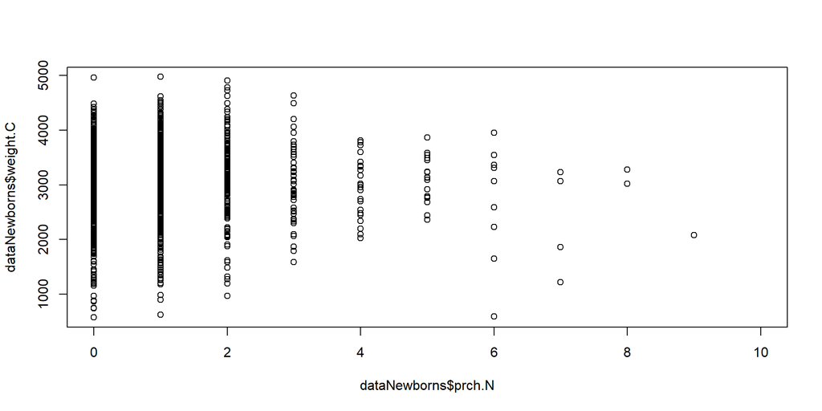

```r
plot(
  dataNewborns$prch.N,
  dataNewborns$weight.C,
  type = "p",
  xlim = c(0,10))
```

## base R vs `ggplot2`

Now lets try something more complicated. How about a graph that would be showing us birth weight distribution by sex?

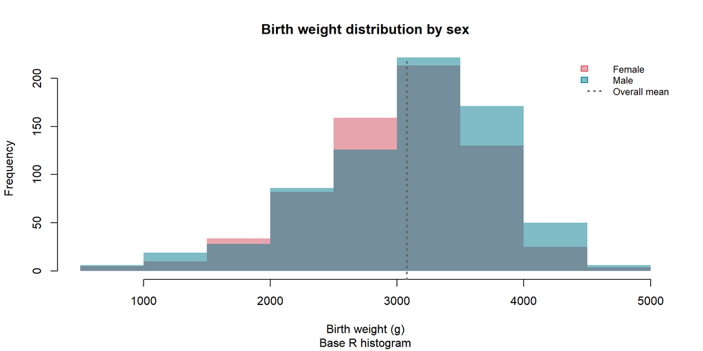

```r
histogram_breaks <- round(1 + 3.3 * log10(length(dataNewborns$weight.C)))

histogram_colours <- c(Female = "#D1495B", Male = "#00798C")

female_weights <- dataNewborns$weight.C[dataNewborns$sex.C == "Female"]
male_weights <- dataNewborns$weight.C[dataNewborns$sex.C == "Male"]

hist(female_weights,
    breaks = histogram_breaks,
    col = adjustcolor(histogram_colours["Female"], alpha.f = 0.50),
    border = NA,
    xlab = "Birth weight (g)",
    ylab = "Frequency",
    main = "Birth weight distribution by sex",
    sub = "Base R histogram")

hist(male_weights,
    breaks = histogram_breaks, add = TRUE,
    col = adjustcolor(histogram_colours["Male"], alpha.f = 0.50),
    border = NA)

abline(v = mean(dataNewborns$weight.C), col = "grey35", lty = 3, lwd = 2)

legend("topright",
    legend = c("Female", "Male", "Overall mean"),
    fill = c(adjustcolor(histogram_colours, alpha.f = 0.50), NA),
    border = c(histogram_colours, NA),
    col = c(histogram_colours["Female"], histogram_colours["Male"], "grey35"),
    lty = c(NA, NA, 3), lwd = c(1, 1, 2),
    bty = "n", cex = 0.8)
```

As we can see, this one is much more complicated and lengthy. Is there any way that this could be simplified?

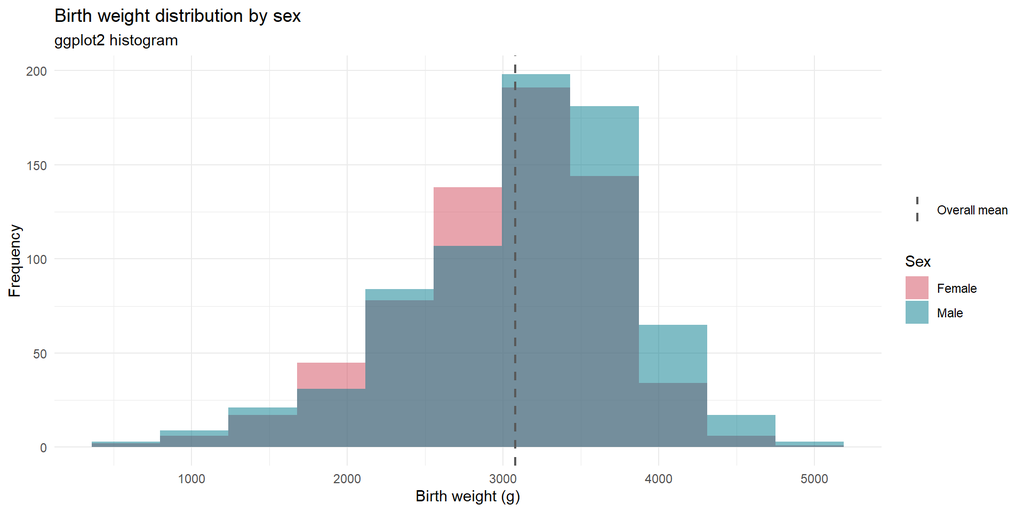

```r
library(ggplot2)
ggplot(dataNewborns, aes(x = weight.C, fill = sex.C)) +
  geom_histogram(bins = round(1 + 3.3 * log10(length(dataNewborns$weight.C))), position = "identity", alpha = 0.50) +
  geom_vline(aes(xintercept = mean(weight.C),
                 linetype = "Overall mean"), colour = "grey35", linewidth = 0.8) +
  scale_fill_manual(values = c("#D1495B","#00798C")) +
  scale_linetype_manual(values = c("Overall mean" = "dashed"),
                        name = NULL) +
  labs(
    title = "Birth weight distribution by sex",
    subtitle = "ggplot2 histogram",
    x = "Birth weight (g)", y = "Frequency", fill = "Sex"
  ) +
  theme_minimal()
```

## Why you should use `ggplot2` instead of `base R`

This is a personal opinion; base R on its own is already a powerful tool. The `ggplot2` package only builds on top of an already existing robust system.

### Pros

- in base R, each type of graph has its own function with what can be wildly varying arguments
  - ggplot2 has in my opinion much **easier and faster to understand grammar**
  - most of the arguments from base R can be used in `ggplot2` anyway
- allows to set up the needed data modifications inside the visualization code; no need to modify the data outside of it
- the baseline results without any extra tweaking looks better than base R
  - of course you can modify the visuals but we are lazy and want the least amount of work possible

### Cons

- **data needs to be a dataframe or a tibble**, the rest will need to be converted

## `ggplot2` grammar: the basics

- `ggplot()` function:
  - argument `data`: what data do we want to visualize?
  - argument `aes()`: How do we want to visualize those data? Which variables from our data do we want to use in the graph? What will be `x`, what will be `y`? Do we want to divide the variables by certain categories?
- `geom_*()` function: Which type of graph do we want? Histogram? Barplot? Do we want them to have any special attributes? What about colours?

The mentioned three functions/arguments are the basic grammar that always has to be used in the `ggplot`. **There are however many additional functions that can be used to create greatly customizable visualizations.**

- all of those functions **have to be applied together** into one graph **using the symbol** **+**
- there is **no limit to how many layers one can apply together**; it is actually possible to even have multiple types of visualization (geom layers) in one graph
  - each new `geom()` layer can have its own `aes` mapping with different arguments’

**It is possible to customize the functions themselves**

Before adding another layer to the `ggplot`, think; is it possible to instead reach the needed result using just the arguments inside each function?

## Barplot

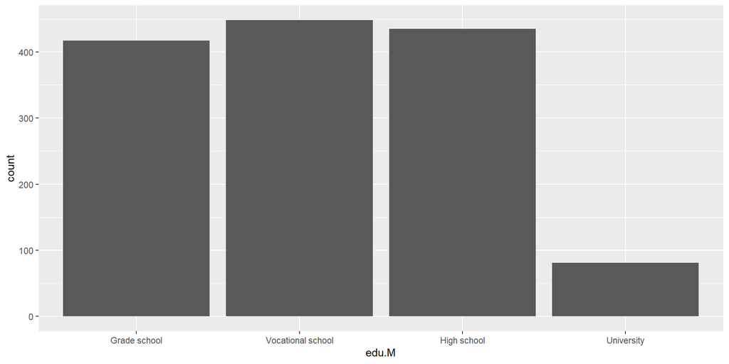

```r
#when starting dont forget to always load the package!
library(ggplot2)
ggplot(data = dataNewborns,
  aes(x = edu.M)) + #geom_bar automatically counts the values of x if y is not provided
  geom_bar() #create barplot
```

**What if we however had the y?**

```r
eduFreq <- data.frame(edu.M = levels(dataNewborns$edu.M),
                      frequency = as.vector(table(dataNewborns$edu.M))); eduFreq
```

```
              edu.M frequency
1      Grade school       417
2 Vocational school       448
3       High school       435
4        University        81
```

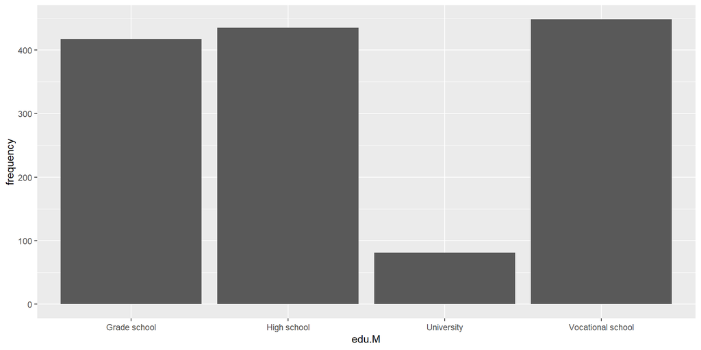

```r
ggplot(data = eduFreq,
       aes(x = edu.M, y = frequency)) +
  geom_bar(stat = "identity") #we want to use specific values not count
```

```r
#notice the reordering!
```

Another option is using `geom_col().` In this case it will offer the same result as previous code, but unlike `geom_bar()` it is meant to be used when summary statistics are available.

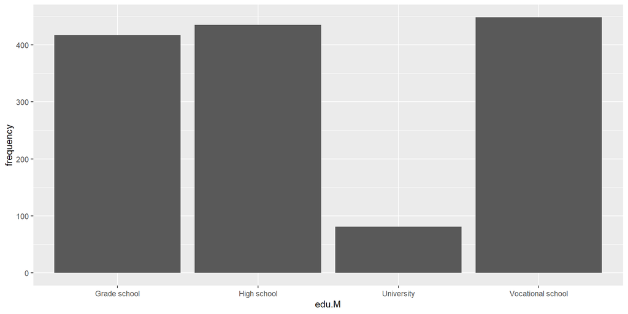

```r
ggplot(data = eduFreq,
       aes(x = edu.M, y = frequency)) +
  geom_col()
```

**Next section: code along to try out different `ggplot2` layers**

#### Individual work

Create a barplot showing the average weight of newborns for mothers from each education level category. Try using colors, legend, labels and all the bells and whistles.

If you will have problem figuring out how to create the dataframe of the average weight, there is one of the many possible solutions on the next slide.

```r
meanWeightEdu <- dataNewborns %>%
  group_by(edu.M) %>%
  summarise(meanWeight = round(mean(weight.C), 2))
```

## Histogram

R will automatically assign into how many “bins” should the data be divided. However, there exists a dedicated formula, that will calculate the optimal amount of bins; the **Sturges’s rule**.

```r
round(1 + 3.3 * log10(length(dataNewborns$weight.C)))
```

```
[1] 11
```

The resulting number can be used in the corresponding argument.

```r
ggplot(dataNewborns) +
  aes(x = weight.C) +
  geom_histogram(bins = 11)
```

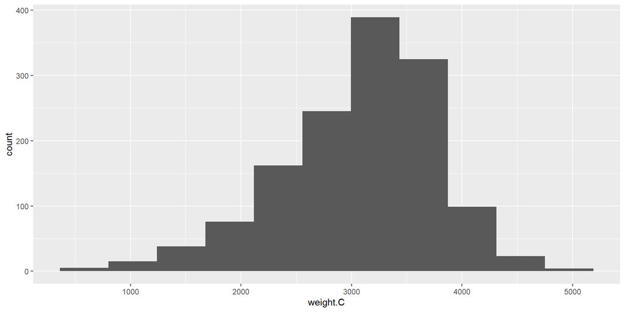

**Next section: code along to try out different `ggplot2` layers**

#### Individual work

Create a histogram using the inbuilt dataset **diamonds**, showing the distribution of the price according to the different cuts. Divide the histogram into individual graph for each cut type. Each graph will have its own color. Don’t forget legend.

## Scatterplot

For this visualization we will be using the inbuilt dataset `iris`.

```r
ggplot(iris, aes(x = Sepal.Length, y = Sepal.Width)) +
  geom_point()
```

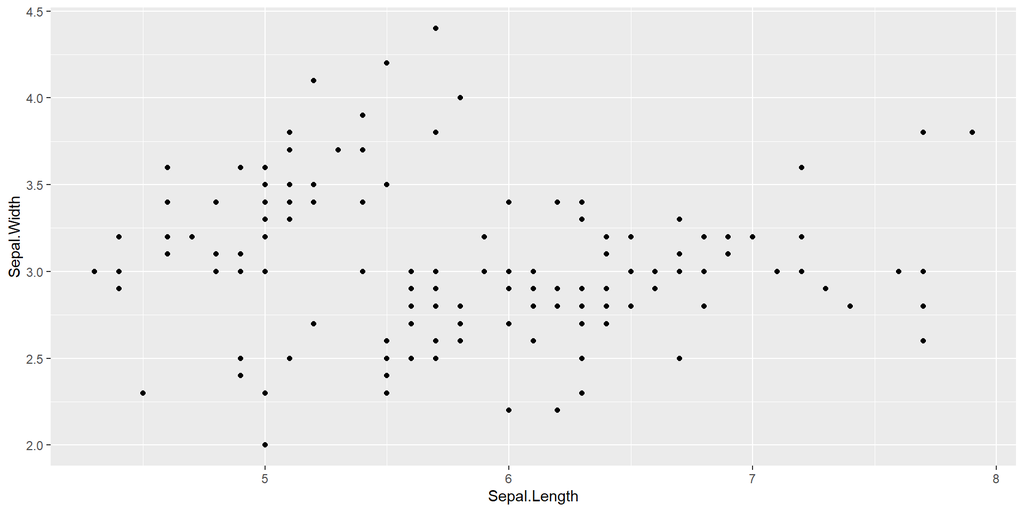

**Next section: code along to try out different `ggplot2` layers**

#### Individual work

Create a scatterplot from the inbuilt dataset `women`. Change the color, size and shape of the points. Add fitted trend line of linear regression.

## Boxplot

Designed to visualize the **distribution of quantitative data in distinct categories**. It specifies the median, IQR, minimum, maximum, and values outside the confidence interval.

```r
ggplot(dataNewborns) +
  aes(x = sex.C, #what category are we using
      y = weight.C) + #what is the numeric value we are plotting
  geom_boxplot()
```

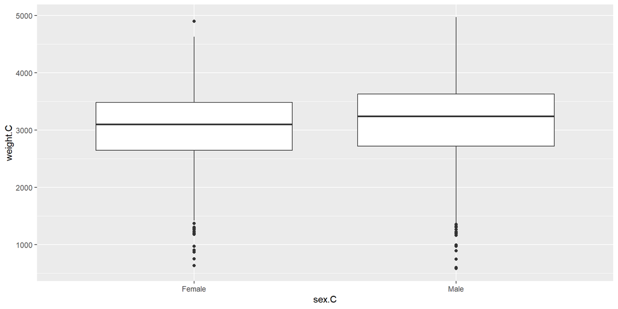

**Next section: code along to try out different `ggplot2` layers**

#### Individual work

Using the dataset `iris`, create a boxplot comparing **Sepal Length** across the three species. Use all the additional layers we learned. Try to write the arguments instead of copying them.

## Heatmaps

Heatmap allows to represent the magnitude of values in a dataset using colours.

Because of that, the only value that can go into the heatmap is a **matrix;** object made out of purely numerical values-

To see an example of how this works, lets take a look at a dataset `eurodist`, which stores information about the distances between various european cities.

```r
dataEU <- as.matrix(eurodist)
heatmap(x = dataEU, #which data we want to load
        col = rainbow(length(eurodist)), #generate as many colors as values in eurodist
        main = "Distances between EU cities")
```

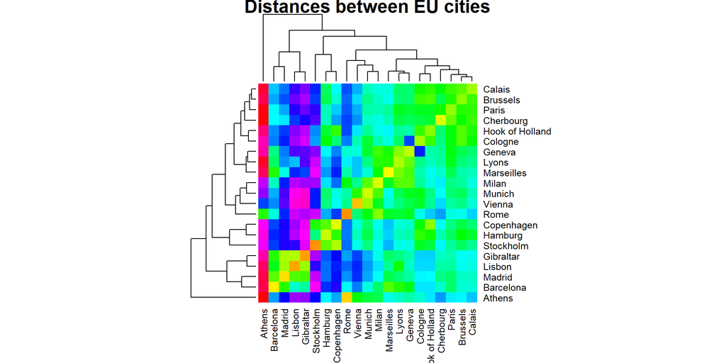

**By default, heatmap() performs hierarchical clustering.**

That means R attempts to arrange the rows and columns so that similar observations are placed near one another. You can see this not only in the color shift, but also by the dendrogram that shows the degrees of closeness between each cities.

## Spatial data

There are **many various different ways how spatial data could be portrayed** using R; from chloropleth, hexbin maps, to interactive maps using the package `leaflet`.  
However, today we are going to focus on the most basic spatial data visualization; placing spots with certain longitude and latitude on a map. This is so you can learn the basics of working with so called **shapefiles (sf)**.

```r
#to work with spatial data certain packages are needed
library(sf)
library(ggplot2)
library(rnaturalearth)
library(rnaturalearthdata)
```

Latitude and longitude of certain points can be easily written as a dataframe.

```r
cities <- data.frame(
  city = c(
    "London",
    "Paris",
    "Berlin",
    "Rome",
    "Prague"),
  longitude = c(
    -0.1276,
    2.3522,
    13.4050,
    12.4964,
    14.4378),
  latitude = c(
    51.5074,
    48.8566,
    52.5200,
    41.9028,
    50.0755)); cities
```

```
    city longitude latitude
1 London   -0.1276  51.5074
2  Paris    2.3522  48.8566
3 Berlin   13.4050  52.5200
4   Rome   12.4964  41.9028
5 Prague   14.4378  50.0755
```

Now we have the coordinates of the points we would want to place. But where? First **we have to create a map, or rather an object with the informations about the shape of the map**.

```r
world <- ne_countries( #geographic data for all countries
  scale = "medium", #how detailed should the map be (try small and large too :])
  returnclass = "sf") #return sf object

class(world) #what sort of object world is?
```

```
[1] "sf"         "data.frame"
```

The next step is converting our data frame with latitude/longitude information into a data structure, that can be sent into the world map shape file.

```r
cities_sf <- st_as_sf( #convert different object to an sf class object
  x = cities, #object to be converted
  coords = c("longitude", "latitude"), #which columns contain the coordinates
  crs = 4326) #coordinate system WGS 84)
```

And now we can complete everything together using the `ggplot2` package.

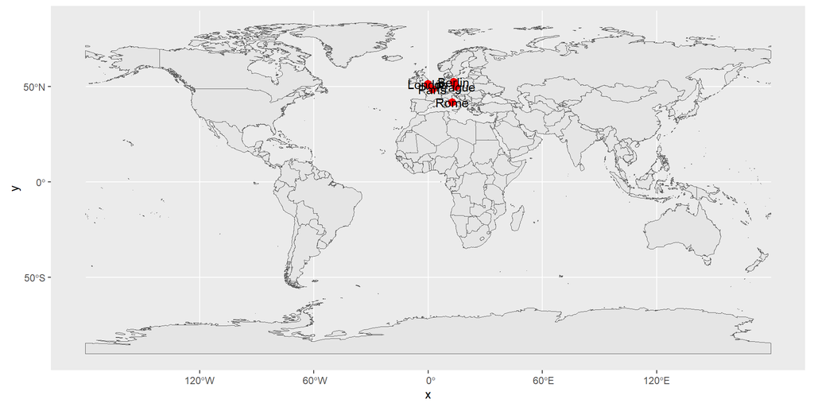

```r
ggplot() + #create a plot
  geom_sf(data = world) + #layer sf data of the map
  geom_sf(
    data = cities_sf, #layer sf data of the points
    color = "red",
    size = 3) +
  geom_sf_text( #add descriptions
    data = cities_sf,
    aes(label = city))
```

Like this, the map is too big for us to see the saved cities properly. Using another `ggplot2` layer `cood_sf`, we can “zoom in”.

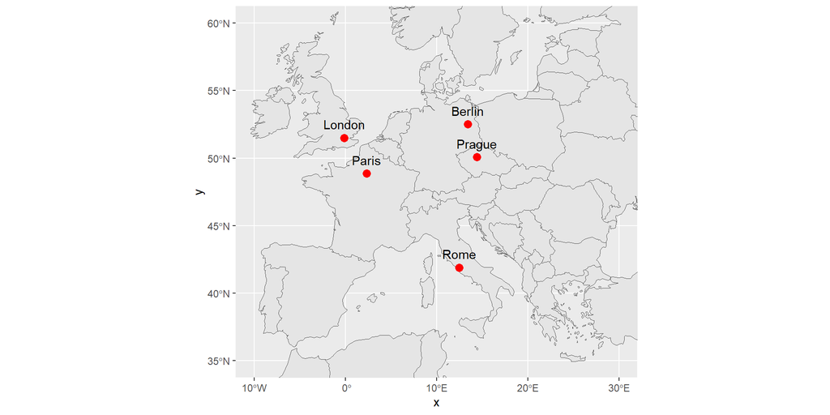

```r
ggplot() +
  geom_sf(data = world) +
  geom_sf(
    data = cities_sf,
    color = "red",
    size = 3) +
  geom_sf_text(
    data = cities_sf,
    aes(label = city),
    nudge_y = 1) + #move the description a little up
  coord_sf( #select only part of the map
    xlim = c(-10, 30), #coordinates on t x axis
    ylim = c(35, 60)) #coordinates on the y axis
```

## Where to next?

[The R Graph Gallery](https://r-graph-gallery.com/)

If you need informations and example of how to create nearly any plot, they have it.

[R Color Palettes: The Complete Reference](https://www.datanovia.com/blog/r-color-palettes)

All the colours and palettes you ahve ever needed.

[R Graphics Cookbook](https://r-graphics.org/)

Takes all the basics we have covered today and adds layers of addjustements. With examples and step by step code.

[Wada Sanzo | A Dictionary of Color Combinations](https://sanzo-wada.dmbk.io/)

Get color combinations for any colour imaginable!